# EDA_p2

## Mud card

- **Can you say more about creating deep/shallow copys of dataframes or other object you might be working with?**
  - Check out the [pandas manual](https://pandas.pydata.org/pandas-docs/version/0.23/generated/pandas.DataFrame.copy.html) on the topic
  - A shallow copy creates a new DataFrame object, but the data within the DataFrame is still referenced from the original DataFrame. This means that modifying the data in the shallow copy will also modify the data in the original DataFrame, and vice versa.
  - A deep copy creates a completely independent copy of the DataFrame, including the data within it. This means that modifying the data in the deep copy will not affect the original DataFrame, and vice versa.
- **How does one negotiate manipulating the column Index and the row Index for more practical/efficient searches in practice?**
  - That's a tough question because it really depends on the problem you are trying to solve
  - there will be some dataframe filtering exercises in PS2 to practice
- **I understand conceptually merge datasets, but I'm worried I'll mess up the order when I merge depending on which arugment I put first**
  - this is why you need to print out the dataframe and make sure it looks correct
  - check and test your work
- **I can't access the class files through jupyter notebook as my command line won't recognise git clone**
  - come to the office hours, the TA will help
- **I am a bit confused why we sometimes needs two sets of brackets instead of 1. For example when we were selecting certain columns, we had columns[[1,5,7]] instead of just columns[1,5,7]**
  - Single brackets [] are used for single-dimensional indexing or accessing a single column by its label or position. For example, columns[1] would return the item (or column) at position 1.
  - Double brackets [[]] are used for multi-dimensional indexing or accessing multiple elements at once. For example, columns[[1, 5, 7]] is used to retrieve multiple columns (in this case, at positions 1, 5, and 7).
- **how to load github data into jupyter notebook**
  - not sure what you mean, please come to the office hours
  - is this for the final project?

# Exploratory data analysis in python, part 2

# Learning objectives

### By the end of this lecture, you will be able to

- visualize one column (categorical, ordinal, and continuous data)
- visualize column pairs (all variations of continuous and categorical columns)
- visualize multiple columns simultaneously

## Dataset of the day

Adult dataset, see [here](https://archive.ics.uci.edu/ml/datasets/Adult)

## Packages of the day

matplotlib and pandas

### By the end of this lecture, you will be able to

- **visualize one column (categorical, ordinal, and continuous data)**
- visualize column pairs (all variations of continuous and categorical columns)
- visualize multiple columns simultaneously

## Data types

- **continuous data**: represented by floating point numbers usually (not always), it is a measured quantity with some unit of measurement (not always)
  - age measured in years
  - distance measured in km or miles
  - weight measured in kg or lbs
  - rates are dimensionless but usually continuous e.g., click-through rates
- **ordinal data**: not continuous data, there are a small number of categories and the categories can be ordered
  - satisfaction levels (satisfied, moderately satisfied, not satisfied)
  - ratings (1-5 stars or ratings like fair, average, good, excellent)
  - time categories like day of the week, month of the year
  - education level
- **categorical data**: there are a small number of categories and the categories cannot be ordered
  - demographic info like race, gender, or marital status
  - blood type
  - eye color
  - type of rock (igneous, sedimentary or metamorphic)

A feature's data type can sometimes be context-dependent or unclear!

- e.g., blood type could be considered ordinal in certain medical situations.
- Would people's birth year be continuous or ordinal?

## Let's load the data first!

```python
import pandas as pd
import numpy as np
import matplotlib
from matplotlib import pylab as plt
df = pd.read_csv('data/adult_data.csv')
print(df.dtypes)
```

```
age                int64
workclass         object
fnlwgt             int64
education         object
education-num      int64
marital-status    object
occupation        object
relationship      object
race              object
sex               object
capital-gain       int64
capital-loss       int64
hours-per-week     int64
native-country    object
gross-income      object
dtype: object
```

### Column is continuous

```python
print(df['age'].describe())
```

```
count    32561.000000
mean        38.581647
std         13.640433
min         17.000000
25%         28.000000
50%         37.000000
75%         48.000000
max         90.000000
Name: age, dtype: float64
```

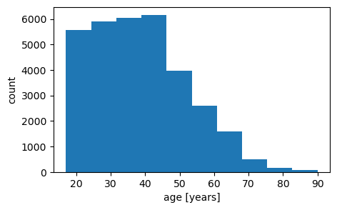

```python
plt.figure(figsize=(5,3))

df['age'].plot.hist()   # bins = int(np.sqrt(df.shape[0]))
                        # bins = df['age'].nunique()
plt.xlabel('age [years]')
plt.ylabel('count')
plt.show()
```

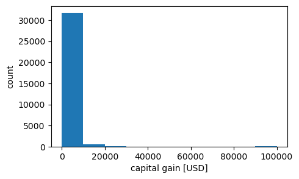

```python
plt.figure(figsize=(5,3))

df['capital-gain'].plot.hist() # log=True, bins = np.logspace(np.log10(1),np.log10(np.max(df['capital-gain'])),50)
#plt.semilogy()
#plt.semilogx()
plt.xlabel('capital gain [USD]')
plt.ylabel('count')
plt.show()
```

### Column is categorical

```python
print(df['occupation'].value_counts())
```

```
occupation
Prof-specialty       4140
Craft-repair         4099
Exec-managerial      4066
Adm-clerical         3770
Sales                3650
Other-service        3295
Machine-op-inspct    2002
?                    1843
Transport-moving     1597
Handlers-cleaners    1370
Farming-fishing       994
Tech-support          928
Protective-serv       649
Priv-house-serv       149
Armed-Forces            9
Name: count, dtype: int64
```

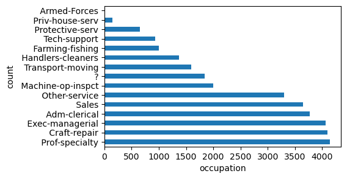

```python
plt.figure(figsize=(5,3))
df['occupation'].value_counts().plot.barh()
plt.ylabel('count')
plt.xlabel('occupation')
plt.show()
```

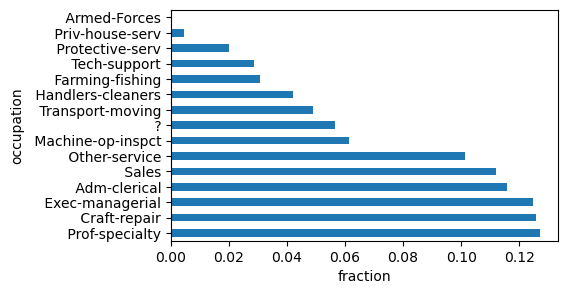

```python
plt.figure(figsize=(5,3))
df['occupation'].value_counts(normalize=True).plot.barh()
plt.xlabel('fraction')
plt.show()
```

# Quiz 1

- What's wrong with this figure?

[figure not shown]

## Ordinal features

[figure not shown]

- other examples of ordinal features:
  - measure of quality (e.g., bad, average, good, excellent)
  - socioeconomic status (e.g., low income, middle income, high income)
  - education level (e.g., 8th grade, high school, BSc, MSc, PhD)
  - satisfaction rating (e.g., dislike, neutral, like)
  - time (e.g., days of the week, months, years)

## The categories of an ordinal feature must be visualized in the correct order!

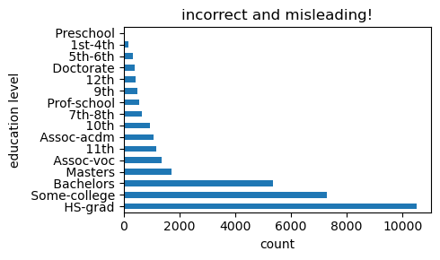

```python
plt.figure(figsize=(5,3))
df['education'].value_counts().plot.barh()
plt.xlabel('count')
plt.ylabel('education level')
plt.title('incorrect and misleading!')
plt.tight_layout()
plt.show()
```

```python
df['education'].value_counts()
```

```
education
HS-grad         10501
Some-college     7291
Bachelors        5355
Masters          1723
Assoc-voc        1382
11th             1175
Assoc-acdm       1067
10th              933
7th-8th           646
Prof-school       576
9th               514
12th              433
Doctorate         413
5th-6th           333
1st-4th           168
Preschool          51
Name: count, dtype: int64
```

```python
correct_order = [' Preschool', ' 1st-4th', ' 5th-6th', ' 7th-8th', ' 9th', ' 10th', ' 11th', \
         ' 12th', ' HS-grad', ' Some-college', ' Assoc-voc', ' Assoc-acdm', ' Bachelors',\
         ' Masters', ' Prof-school', ' Doctorate']

df['education'].value_counts().reindex(correct_order)
```

```
education
Preschool          51
1st-4th           168
5th-6th           333
7th-8th           646
9th               514
10th              933
11th             1175
12th              433
HS-grad         10501
Some-college     7291
Assoc-voc        1382
Assoc-acdm       1067
Bachelors        5355
Masters          1723
Prof-school       576
Doctorate         413
Name: count, dtype: int64
```

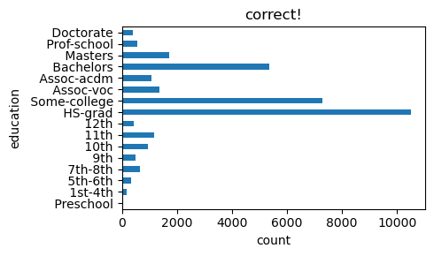

```python
plt.figure(figsize=(5,3))

df['education'].value_counts().reindex(correct_order).plot.barh()
plt.xlabel('count')
plt.ylabel('education')
plt.title('correct!')
plt.tight_layout()
plt.show()
```

### By the end of this lecture, you will be able to

- visualize one column (categorical, ordinal, and continuous data)
- **visualize column pairs (all variations of continuous and categorical columns)**
- visualize multiple columns simultaneously

## Overview

| *Visualization types* | column continuous | column categorical |
| --- | --- | --- |
| **column continuous** | scatter plot, heatmap | category-specific histograms, box plot, violin plot |
| **column categorical** | category-specific histograms, box plot, violin plot | stacked bar plot |

### Continuous vs. continuous columns

- scatter plot

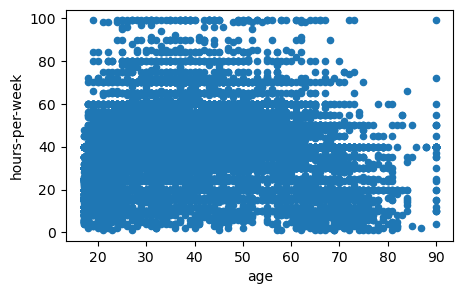

```python
df.plot.scatter('age','hours-per-week',figsize=(5,3)) # alpha=0.1,s=10
plt.show()
```

### Continuous vs. continuous columns

- heatmap

```python
nbins = 40

heatmap, xedges, yedges = np.histogram2d(df['age'], df['hours-per-week'], bins=nbins)
extent = [xedges[0], xedges[-1], yedges[0], yedges[-1]]
```

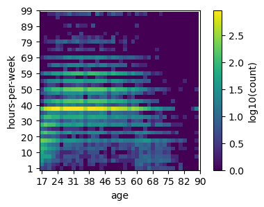

```python
heatmap[heatmap == 0] = 0.1 # we will use log and log(0) is undefined
plt.figure(figsize=(5,3))

plt.imshow(np.log10(heatmap).T, origin='lower',vmin=0) # use log count
#plt.imshow(heatmap.T, origin='lower',vmin=0) # use log count
plt.xlabel('age')
plt.ylabel('hours-per-week')
plt.xticks(np.arange(nbins+1)[::4],xedges[::4].astype(int))
plt.yticks(np.arange(nbins+1)[::4],yedges[::4].astype(int))
plt.colorbar(label='log10(count)')
plt.show()
```

### Categorical vs. categorical columns

- stacked bar plot

```python
count_matrix = df.groupby(['race', 'gross-income']).size().unstack()
print(count_matrix)

count_matrix_norm = count_matrix.div(count_matrix.sum(axis=1),axis=0)
print(count_matrix_norm)
```

```
gross-income        <=50K  >50K
race
Amer-Indian-Eskimo    275    36
Asian-Pac-Islander    763   276
Black                2737   387
Other                 246    25
White               20699  7117
gross-income           <=50K      >50K
race
Amer-Indian-Eskimo  0.884244  0.115756
Asian-Pac-Islander  0.734360  0.265640
Black               0.876120  0.123880
Other               0.907749  0.092251
White               0.744140  0.255860
```

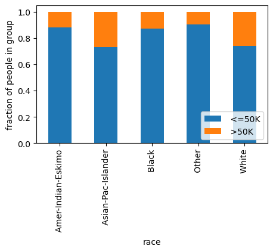

```python
count_matrix_norm.plot(kind='bar', stacked=True,figsize=(5,3))
plt.ylabel('fraction of people in group')
plt.legend(loc=4)
plt.show()
```

### Continuous vs. categorical columns

- category-specific histograms

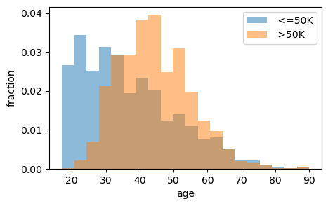

```python
import matplotlib
from matplotlib import pylab as plt

categories = df['gross-income'].unique()
bin_range = (df['age'].min(),df['age'].max())

plt.figure(figsize=(5,3))

for c in categories:
    plt.hist(df[df['gross-income']==c]['age'],alpha=0.5,label=c,range=bin_range,bins=20,density=True)
plt.legend()
plt.ylabel('fraction')
plt.xlabel('age')
plt.show()
```

### Continuous vs. categorical columns

- box plot

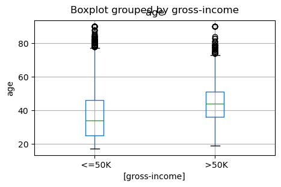

```python
df[['age','gross-income']].boxplot(by='gross-income',figsize=(5,3))
plt.ylabel('age')
plt.show()
```

### Continuous vs. categorical columns

- violin plot

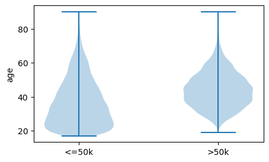

```python
dataset = [df[df['gross-income']==' <=50K']['age'].values,
           df[df['gross-income']==' >50K']['age'].values]

plt.figure(figsize=(5,3))

plt.violinplot(dataset = dataset)
plt.xticks([1,2],['<=50k','>50k'])
plt.ylabel('age')
plt.show()
```

```python
help(plt.violinplot)
```

[output not shown]

[output cut: 47 more lines]

```
      - ``cquantiles``: A `~.collections.LineCollection` instance created
        to identify the quantile values of each of the violin's
        distribution.

    See Also
    --------
    .Axes.violin : Draw a violin from pre-computed statistics.
    boxplot : Draw a box and whisker plot.

    Notes
    -----

    .. note::

        This is the :ref:`pyplot wrapper <pyplot_interface>` for `.axes.Axes.violinplot`.
```

## Quiz 2

Pair the column name(s) with the appropriate visualization type!

### By the end of this lecture, you will be able to

- visualize one column (categorical, ordinal, and continuous data)
- visualize column pairs (all variations of continuous and categorical columns)
- **visualize multiple columns simultaneously**

#### Scatter matrix

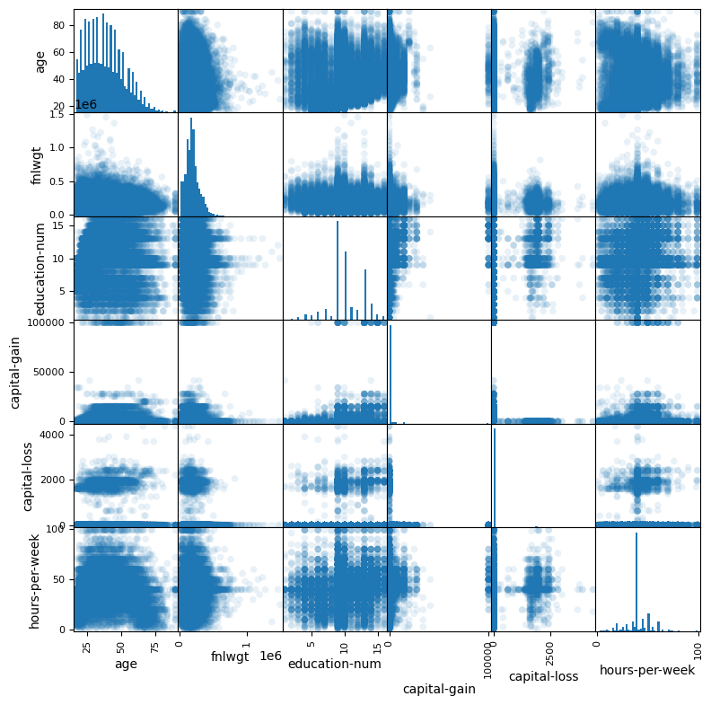

```python
pd.plotting.scatter_matrix(df.select_dtypes(int), figsize=(9, 9), marker='o',hist_kwds={'bins': 50},
                           s=30, alpha=.1)
plt.show()
```

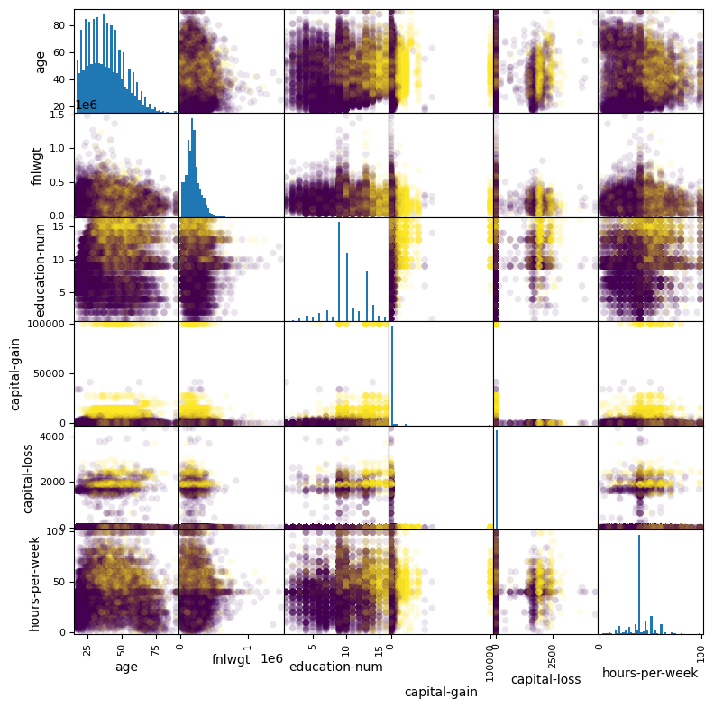

```python
pd.plotting.scatter_matrix(df.select_dtypes(int), figsize=(9, 9),c = pd.get_dummies(df['gross-income']).iloc[:,1],
                           marker='o',hist_kwds={'bins': 50}, s=30, alpha=.1)
plt.show()
```

### By now, you can

- visualize one column (continuous or categorical data)
- visualize column pairs (all variations of continuous and categorical columns)
- visualize multiple columns simultaneously

## [Matplotlib cheatsheets!](https://github.com/matplotlib/cheatsheets)

The cheatsheets in this repo are excellent. Feel free to use them any time!

## Other great resources for visualization

DATA1500 - Data Visualization & Narrative (Course offered in the spring term)

https://www.data-to-viz.com/

https://pyviz.org/